# Bellabeat Smart Device Fitness Data Analysis

Abeer

2022-12-19

[figure not shown]

### Business task:

Analyze non Bellabeat smart device usage data to identify trends. Then, using this information, make high-level recommendations for how these trends can inform Bellabeat marketing strategy.

### Setting up the environment

setting up my R environment by loading the following packages:

```r
library(tidyverse)
```

```r
library(ggplot2)
library(readr)
library(janitor)
library(gridExtra)
```

### Importing the data

after inspecting the data in excel it appears that the `dailyCalories_merged.csv`, `dailyIntensities_merged.csv`, `dailySteps_merged.csv` have been merged into `dailyActivity_merged.csv`. So, I will only use the following:

```r
daily_activity <- read.csv("/Users/Abeer/Desktop/Google Data Analytics/Bellabeat-Smart-Device-Fitness-Data-Analysis/Bellabeat-case-study/Fitabase Data 4.12.16-5.12.16/dailyActivity_merged.csv")
daily_sleep <- read.csv("/Users/Abeer/Desktop/Google Data Analytics/Bellabeat-Smart-Device-Fitness-Data-Analysis/Bellabeat-case-study/Fitabase Data 4.12.16-5.12.16/sleepDay_merged.csv")
weight <- read.csv("/Users/Abeer/Desktop/Google Data Analytics/Bellabeat-Smart-Device-Fitness-Data-Analysis/Bellabeat-case-study/Fitabase Data 4.12.16-5.12.16/weightLogInfo_merged.csv")
hourly_steps <- read.csv("/Users/Abeer/Desktop/Google Data Analytics/Bellabeat-Smart-Device-Fitness-Data-Analysis/Bellabeat-case-study/Fitabase Data 4.12.16-5.12.16/hourlySteps_merged.csv")
hourly_intensities <- read.csv("/Users/Abeer/Desktop/Google Data Analytics/Bellabeat-Smart-Device-Fitness-Data-Analysis/Bellabeat-case-study/Fitabase Data 4.12.16-5.12.16/hourlyIntensities_merged.csv")
```

### Data cleaning

Take a look at the data & clean the columns names

```r
daily_activity <- daily_activity %>% clean_names()
daily_sleep <- daily_sleep %>% clean_names()
weight <- weight %>% clean_names()
hourly_steps <- hourly_steps %>% clean_names()
hourly_intensities <- hourly_intensities %>% clean_names()
head(daily_activity)
```

```
##           id activity_date total_steps total_distance tracker_distance
## 1 1503960366     4/12/2016       13162           8.50             8.50
## 2 1503960366     4/13/2016       10735           6.97             6.97
## 3 1503960366     4/14/2016       10460           6.74             6.74
## 4 1503960366     4/15/2016        9762           6.28             6.28
## 5 1503960366     4/16/2016       12669           8.16             8.16
## 6 1503960366     4/17/2016        9705           6.48             6.48
##   logged_activities_distance very_active_distance moderately_active_distance
## 1                          0                 1.88                       0.55
## 2                          0                 1.57                       0.69
## 3                          0                 2.44                       0.40
## 4                          0                 2.14                       1.26
## 5                          0                 2.71                       0.41
## 6                          0                 3.19                       0.78
##   light_active_distance sedentary_active_distance very_active_minutes
## 1                  6.06                         0                  25
## 2                  4.71                         0                  21
## 3                  3.91                         0                  30
## 4                  2.83                         0                  29
## 5                  5.04                         0                  36
## 6                  2.51                         0                  38
##   fairly_active_minutes lightly_active_minutes sedentary_minutes calories
## 1                    13                    328               728     1985
## 2                    19                    217               776     1797
## 3                    11                    181              1218     1776
## 4                    34                    209               726     1745
## 5                    10                    221               773     1863
## 6                    20                    164               539     1728
```

```r
head(daily_sleep)
```

```
##           id             sleep_day total_sleep_records total_minutes_asleep
## 1 1503960366 4/12/2016 12:00:00 AM                   1                  327
## 2 1503960366 4/13/2016 12:00:00 AM                   2                  384
## 3 1503960366 4/15/2016 12:00:00 AM                   1                  412
## 4 1503960366 4/16/2016 12:00:00 AM                   2                  340
## 5 1503960366 4/17/2016 12:00:00 AM                   1                  700
## 6 1503960366 4/19/2016 12:00:00 AM                   1                  304
##   total_time_in_bed
## 1               346
## 2               407
## 3               442
## 4               367
## 5               712
## 6               320
```

```r
head(weight)
```

```
##           id                  date weight_kg weight_pounds fat   bmi
## 1 1503960366  5/2/2016 11:59:59 PM      52.6      115.9631  22 22.65
## 2 1503960366  5/3/2016 11:59:59 PM      52.6      115.9631  NA 22.65
## 3 1927972279  4/13/2016 1:08:52 AM     133.5      294.3171  NA 47.54
## 4 2873212765 4/21/2016 11:59:59 PM      56.7      125.0021  NA 21.45
## 5 2873212765 5/12/2016 11:59:59 PM      57.3      126.3249  NA 21.69
## 6 4319703577 4/17/2016 11:59:59 PM      72.4      159.6147  25 27.45
##   is_manual_report       log_id
## 1             True 1.462234e+12
## 2             True 1.462320e+12
## 3            False 1.460510e+12
## 4             True 1.461283e+12
## 5             True 1.463098e+12
## 6             True 1.460938e+12
```

```r
head(hourly_steps)
```

```
##           id         activity_hour step_total
## 1 1503960366 4/12/2016 12:00:00 AM        373
## 2 1503960366  4/12/2016 1:00:00 AM        160
## 3 1503960366  4/12/2016 2:00:00 AM        151
## 4 1503960366  4/12/2016 3:00:00 AM          0
## 5 1503960366  4/12/2016 4:00:00 AM          0
## 6 1503960366  4/12/2016 5:00:00 AM          0
```

```r
head(hourly_intensities)
```

```
##           id         activity_hour total_intensity average_intensity
## 1 1503960366 4/12/2016 12:00:00 AM              20          0.333333
## 2 1503960366  4/12/2016 1:00:00 AM               8          0.133333
## 3 1503960366  4/12/2016 2:00:00 AM               7          0.116667
## 4 1503960366  4/12/2016 3:00:00 AM               0          0.000000
## 5 1503960366  4/12/2016 4:00:00 AM               0          0.000000
## 6 1503960366  4/12/2016 5:00:00 AM               0          0.000000
```

how many users in each dataset?

```r
n_distinct(daily_activity$id)
```

```
## [1] 33
```

```r
n_distinct(daily_sleep$id)
```

```
## [1] 24
```

```r
n_distinct(weight$id) # only 8 users therefore i will not use it
```

```
## [1] 8
```

```r
n_distinct(hourly_steps$id)
```

```
## [1] 33
```

check for missing and duplicate observations

```r
sum(is.na(daily_activity))
```

```
## [1] 0
```

```r
sum(is.na(daily_sleep))
```

```
## [1] 0
```

```r
sum(is.na(hourly_steps))
```

```
## [1] 0
```

```r
sum(is.na(hourly_intensities))
```

```
## [1] 0
```

```r
sum(duplicated(daily_activity))
```

```
## [1] 0
```

```r
sum(duplicated(daily_sleep))
```

```
## [1] 3
```

```r
sum(duplicated(hourly_steps))
```

```
## [1] 0
```

```r
sum(duplicated(hourly_intensities))
```

```
## [1] 0
```

remove duplicates from `daily_sleep`

```r
daily_sleep <- daily_sleep %>% distinct()
sum(duplicated(daily_sleep))
```

```
## [1] 0
```

we can see that the data type for date columns is char

```r
str(daily_activity)
```

```
## 'data.frame':    940 obs. of  15 variables:
##  $ id                        : num  1.5e+09 1.5e+09 1.5e+09 1.5e+09 1.5e+09 ...
##  $ activity_date             : chr  "4/12/2016" "4/13/2016" "4/14/2016" "4/15/2016" ...
##  $ total_steps               : int  13162 10735 10460 9762 12669 9705 13019 15506 10544 9819 ...
##  $ total_distance            : num  8.5 6.97 6.74 6.28 8.16 ...
##  $ tracker_distance          : num  8.5 6.97 6.74 6.28 8.16 ...
##  $ logged_activities_distance: num  0 0 0 0 0 0 0 0 0 0 ...
##  $ very_active_distance      : num  1.88 1.57 2.44 2.14 2.71 ...
##  $ moderately_active_distance: num  0.55 0.69 0.4 1.26 0.41 ...
##  $ light_active_distance     : num  6.06 4.71 3.91 2.83 5.04 ...
##  $ sedentary_active_distance : num  0 0 0 0 0 0 0 0 0 0 ...
##  $ very_active_minutes       : int  25 21 30 29 36 38 42 50 28 19 ...
##  $ fairly_active_minutes     : int  13 19 11 34 10 20 16 31 12 8 ...
##  $ lightly_active_minutes    : int  328 217 181 209 221 164 233 264 205 211 ...
##  $ sedentary_minutes         : int  728 776 1218 726 773 539 1149 775 818 838 ...
##  $ calories                  : int  1985 1797 1776 1745 1863 1728 1921 2035 1786 1775 ...
```

```r
str(daily_sleep)
```

```
## 'data.frame':    410 obs. of  5 variables:
##  $ id                  : num  1.5e+09 1.5e+09 1.5e+09 1.5e+09 1.5e+09 ...
##  $ sleep_day           : chr  "4/12/2016 12:00:00 AM" "4/13/2016 12:00:00 AM" "4/15/2016 12:00:00 AM" "4/16/2016 12:00:00 AM" ...
##  $ total_sleep_records : int  1 2 1 2 1 1 1 1 1 1 ...
##  $ total_minutes_asleep: int  327 384 412 340 700 304 360 325 361 430 ...
##  $ total_time_in_bed   : int  346 407 442 367 712 320 377 364 384 449 ...
```

```r
str(hourly_steps)
```

```
## 'data.frame':    22099 obs. of  3 variables:
##  $ id           : num  1.5e+09 1.5e+09 1.5e+09 1.5e+09 1.5e+09 ...
##  $ activity_hour: chr  "4/12/2016 12:00:00 AM" "4/12/2016 1:00:00 AM" "4/12/2016 2:00:00 AM" "4/12/2016 3:00:00 AM" ...
##  $ step_total   : int  373 160 151 0 0 0 0 0 250 1864 ...
```

```r
str(hourly_intensities)
```

```
## 'data.frame':    22099 obs. of  4 variables:
##  $ id               : num  1.5e+09 1.5e+09 1.5e+09 1.5e+09 1.5e+09 ...
##  $ activity_hour    : chr  "4/12/2016 12:00:00 AM" "4/12/2016 1:00:00 AM" "4/12/2016 2:00:00 AM" "4/12/2016 3:00:00 AM" ...
##  $ total_intensity  : int  20 8 7 0 0 0 0 0 13 30 ...
##  $ average_intensity: num  0.333 0.133 0.117 0 0 ...
```

fix the date columns format (i will ignore the time in sleep_day since all observations are 12:00:00)

```r
daily_activity$activity_date <- as.Date(daily_activity$activity_date, "%m/%d/%y")

daily_sleep$sleep_day <- as.Date(daily_sleep$sleep_day, "%m/%d/%y")

hourly_steps$activity_hour <- strptime(hourly_steps$activity_hour, "%m/%d/%Y %I:%M:%S %p")
hourly_steps$hour <- strftime(hourly_steps$activity_hour, "%H:%M")

hourly_intensities$activity_hour <- strptime(hourly_intensities$activity_hour, "%m/%d/%Y %I:%M:%S %p")
hourly_intensities$hour <- strftime(hourly_steps$activity_hour, "%H:%M")
```

To identify outliers i will create a boxplot then i will use the IQR method to remove outliers, since the dataset is small and I’m not sure it’s representative of the population of interest i decided to be more conservative and remove only extreme outliers

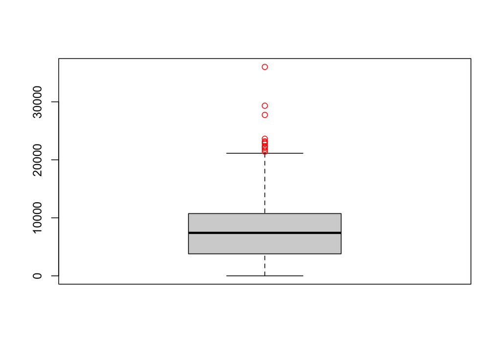

```r
boxplot(daily_activity$total_steps, outcol="red")
```

IQR method

```r
#daily activity total steps
summary(daily_activity$total_steps)
```

```
##    Min. 1st Qu.  Median    Mean 3rd Qu.    Max.
##       0    3790    7406    7638   10727   36019
```

```r
IQR(daily_activity$total_steps)
```

```
## [1] 6937.25
```

```r
Tmin = 3790 - (3 * 6937.25)
Tmax = 10727 + (3 * 6937.25)

#outliers
daily_activity$total_steps[which(daily_activity$total_steps < Tmin | daily_activity$total_steps > Tmax)]
```

```
## [1] 36019
```

```r
#remove outliers
daily_activity <- daily_activity[(daily_activity$total_steps > Tmin & daily_activity$total_steps < Tmax),]
```

### Analysis

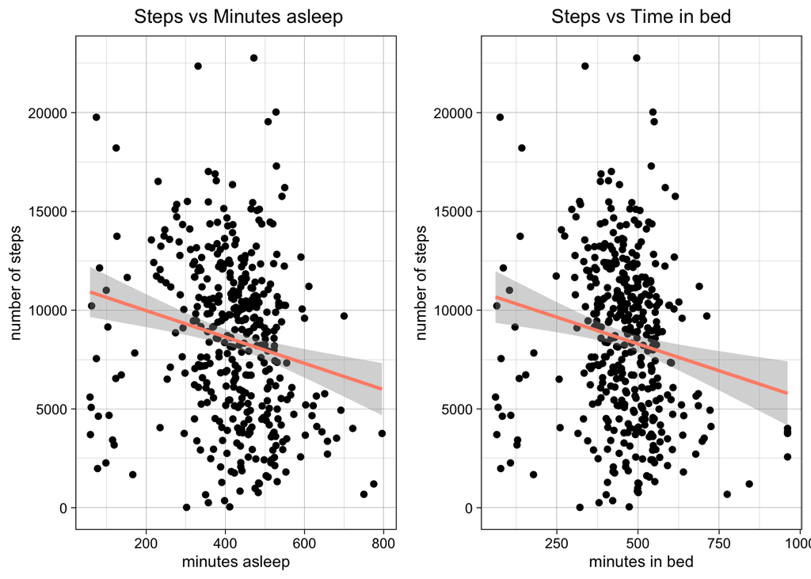

```r
#minutes asleep vs steps

#first i will use rowSums function to sum across rows and create total_intensities_distance column
daily_activity <- daily_activity %>% mutate(total_intensities_distance = rowSums(across(c(light_active_distance, moderately_active_distance, very_active_distance))))
#now i will inner_join daily_sleep and daily_activity to create the plot
daily_sleep <- inner_join(daily_sleep, daily_activity[ , c("id", "activity_date", "total_steps", "sedentary_minutes", "total_intensities_distance")], by = c("id" = "id", "sleep_day" = "activity_date"))

g1 <- ggplot(data = daily_sleep, mapping = aes(x = total_minutes_asleep, y = total_steps)) + geom_point()  + geom_smooth(method = "lm", color = "#fe8f77") + theme_linedraw() +labs(title = " Steps vs Minutes asleep",
         x = "minutes asleep", y = "number of steps") +
    theme(plot.title = element_text(size = 12, hjust = 0.5),
          axis.title.x = element_text(size = 10),
          axis.title.y = element_text(size = 10))

#steps vs time in bed
g2 <- ggplot(data = daily_sleep,mapping = aes(x= total_time_in_bed, y = total_steps)) + geom_point() + geom_smooth(method = "lm", color = "#fe8f77") + theme_linedraw() + labs(title = "Steps vs Time in bed", x = "minutes in bed", y = "number of steps") +
    theme(plot.title = element_text(size = 12, hjust = 0.5),
          axis.title.x = element_text(size = 10),
          axis.title.y = element_text(size = 10))




g1grob <- ggplotGrob(g1)
g2grob <- ggplotGrob(g2)
grid.arrange(g1grob, g2grob, nrow = 1)
```

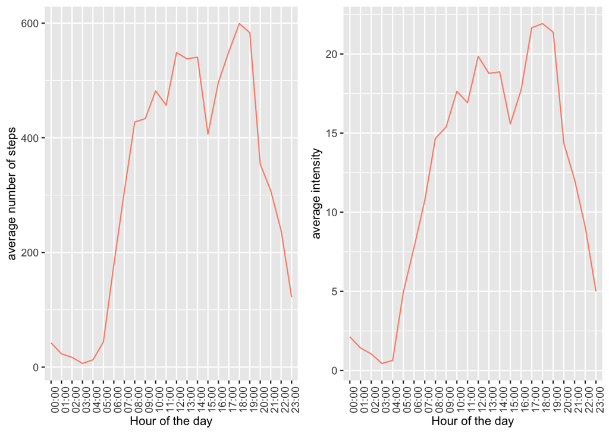

```r
#Steps vs time of the day
steps_time_trends <- hourly_steps %>% group_by(hour) %>%
  summarise(avg_steps_per_hour = mean(step_total)) %>%
  arrange(hour)

g3 <- ggplot(data = steps_time_trends, mapping = aes(x= hour, y = avg_steps_per_hour, group = 1 )) + geom_line(color = "#fe8f77") + theme(axis.text.x = element_text(angle = 90)) + labs(x = "Hour of the day", y = "average number of steps") +
    theme(plot.title = element_text(size = 12, hjust = 0.5),
          axis.title.x = element_text(size = 10),
          axis.title.y = element_text(size = 10))

#intensities vs time of the day
intensity_time_trends <- hourly_intensities %>% group_by(hour) %>%
  summarise(avg_intensity_per_hour = mean(total_intensity)) %>%
  arrange(hour)

g4 <- ggplot(data = intensity_time_trends, mapping = aes(x= hour, y= avg_intensity_per_hour, group = 1)) + geom_line(color = "#fe8f77") + theme(axis.text.x = element_text(angle = 90)) + labs(x = "Hour of the day", y = "average intensity") +
    theme(plot.title = element_text(size = 12, hjust = 0.5),
          axis.title.x = element_text(size = 10),
          axis.title.y = element_text(size = 10))

g3grob <- ggplotGrob(g3)
g4grob <- ggplotGrob(g4)

grid.arrange(g3grob, g4grob, nrow = 1)
```

we can see that users are the most active from 8 AM to 7 PM especially around break time for most 9-5 jobs.

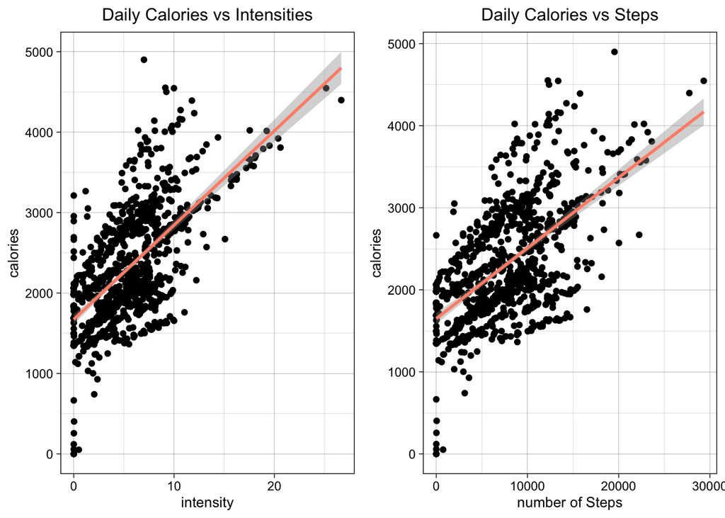

```r
#intensities vs calories
g5 <- ggplot(data = daily_activity, mapping = aes(x = total_intensities_distance, y = calories)) + geom_point() +geom_smooth(method = "lm", color = "#fe8f77") + theme_linedraw() + labs(title = "Daily Calories vs Intensities", x= "intensity", y = "calories") +
    theme(plot.title = element_text(size = 12, hjust = 0.5),
          axis.title.x = element_text(size = 10),
          axis.title.y = element_text(size = 10))


#daily steps vs calories
g6 <- ggplot(data = daily_activity, mapping = aes(x = total_steps, y = calories)) + geom_point() + geom_smooth(method = "lm", color = "#fe8f77") + theme_linedraw() +labs(title = "Daily Calories vs Steps",
         x = "number of Steps", y = "calories") +
    theme(plot.title = element_text(size = 12, hjust = 0.5),
          axis.title.x = element_text(size = 10),
          axis.title.y = element_text(size = 10))
g5grob <- ggplotGrob(g5)
g6grob <- ggplotGrob(g6)
grid.arrange(g5grob, g6grob, nrow = 1)
```

As the intensity and number of steps increase, the calories burned also increases therefore there is a positive correlation.

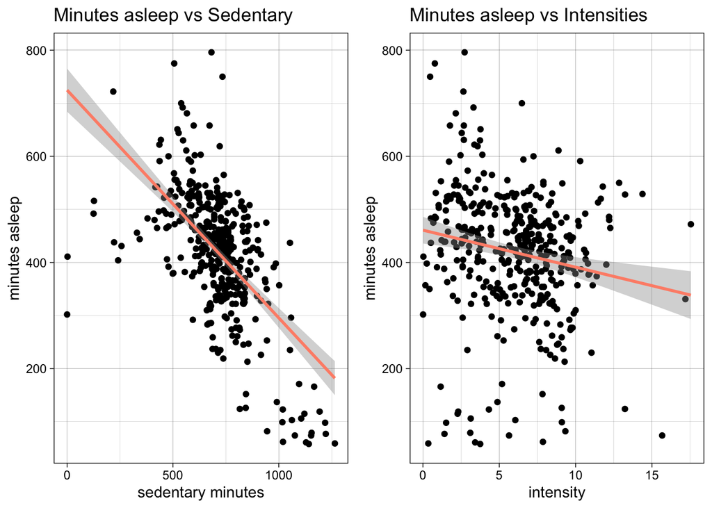

```r
# minutes asleep vs sedentary
g7 <- ggplot(data = daily_sleep, mapping = aes(x = sedentary_minutes, y = total_minutes_asleep)) + geom_point() + geom_smooth(method = "lm", color = "#fe8f77") + theme_linedraw() + labs(title = "Minutes asleep vs Sedentary", x = "sedentary minutes", y = "minutes asleep")

#intensities vs sleep

g8 <- ggplot(data = daily_sleep, mapping = aes(x = total_intensities_distance, y = total_minutes_asleep)) + geom_point() +geom_smooth(method = "lm", color = "#fe8f77") + theme_linedraw() + labs(title = "Minutes asleep vs Intensities", x= "intensity", y = "minutes asleep")

g7grob <- ggplotGrob(g7)
g8grob <- ggplotGrob(g8)
grid.arrange(g7grob, g8grob, nrow = 1)
```

### Conclusion

Bellabeat products empower women with knowledge about their own health and habits, the target audience are women who live a healthy lifestyle.

Recommendations:

- Investigate about what is preventing users from using weight logging.
- Send reminders around the most active hours to increase user engagement and encourage them to take a walk or remind them to drink water.
- Reminders for users who want to improve their sleep to reduce sedentary time.
- Reminders to increase greens intake per day.